# Final Project

Seyedehbahareh Hashemimovahed

2023-05-10

https://github.com/baharhm/DS202/tree/main/FinalProject/FinalProject

### NFL Divisional and None-Divisional Game Analysis Project

#### We are comparing the Divisional and Non-devisional games in NFL and finding out if divisional games have a different total final scores and points.

##### First, we will be reading the datasets provided to us

```r
#Read the data
nfl_scores <- read.csv('spreadspoke_scores.csv')
nfl_scores <- drop_na(nfl_scores)
nfl_scores <- filter(nfl_scores, schedule_season >= 2002)

nfl_teams <- read.csv('nfl_teams.csv')
nfl_teams <- select(nfl_teams, team_name, team_division)
```

##### Now we will be Merging the tables scores and team information to get the division of each team for each game.

```r
nfl_data <- merge(x = nfl_scores, y = nfl_teams, by.x = 'team_home', by.y = 'team_name', all.x = TRUE)
nfl_data <- rename(nfl_data, team_division_home = team_division)
nfl_data <- merge(x = nfl_data, y = nfl_teams, by.x = 'team_away', by.y = 'team_name', all.x = TRUE)
nfl_data <- rename(nfl_data, team_division_away = team_division)
```

##### We need to fix the data by filling in the missing values for Cities.

```r
A <- filter(nfl_data, team_away == 'Las Vegas Raiders')
A$team_division_away <- 'AFC West'
B <- filter(nfl_data, team_away == 'St. Louis Rams')
B$team_division_away <- 'NFC West'
C <- filter(nfl_data, team_home == 'St. Louis Rams')
nfl_data <- filter(nfl_data, team_away != 'Las Vegas Raiders')
nfl_data <- filter(nfl_data, team_away != 'St. Louis Rams')
nfl_data <- filter(nfl_data, team_home != 'St. Louis Rams')
nfl_data <- rbind(nfl_data, A, B, C)
```

##### Here, we are finding the point difference between teams at end of each game and get total for divisional games.

```r
nfl_data <- mutate(nfl_data, pd = abs(score_home-score_away))
nfl_data <- mutate(nfl_data, total = score_home + score_away)
nfl_data <- mutate(nfl_data, divisional_game = ifelse(team_division_home == team_division_away, TRUE, FALSE))

head(nfl_data,10)
```

```
##            team_away           team_home schedule_date schedule_season
## 1  Arizona Cardinals    Seattle Seahawks    11/16/2008            2008
## 2  Arizona Cardinals   Carolina Panthers    12/19/2010            2010
## 3  Arizona Cardinals    Seattle Seahawks    12/26/2004            2004
## 4  Arizona Cardinals    Tennessee Titans    12/15/2013            2013
## 5  Arizona Cardinals   Carolina Panthers    11/21/2004            2004
## 6  Arizona Cardinals Washington Redskins     9/21/2008            2008
## 7  Arizona Cardinals Washington Redskins     9/18/2011            2011
## 8  Arizona Cardinals  Kansas City Chiefs     12/1/2002            2002
## 9  Arizona Cardinals    Seattle Seahawks    12/21/2003            2003
## 10 Arizona Cardinals Philadelphia Eagles    11/17/2002            2002
##    schedule_week schedule_playoff score_home score_away team_favorite_id
## 1             11            FALSE         20         26              ARI
## 2             15            FALSE         19         12              CAR
## 3             16            FALSE         24         21              SEA
```

[output cut: 40 more lines]

###Question 1 ####Are point differentials different for divisional games vs non-divisional? ###Expectation ####point differentials usually don’t differ in divisonal games vs non-divisonal games

```r
df1 <- nfl_data %>%
  group_by(divisional_game) %>%
  summarize(mean_point_diff = mean(abs(score_home - score_away)))
summary(df1)
```

```
##  mean_point_diff
##  Min.   :12.01
##  1st Qu.:12.01
##  Median :12.01
##  Mean   :12.01
##  3rd Qu.:12.01
##  Max.   :12.01
```

```r
df1 <- lm(pd~divisional_game, data = nfl_data)

summary(df1)
```

```
##
## Call:
## lm(formula = pd ~ divisional_game, data = nfl_data)
##
## Residuals:
##     Min      1Q  Median      3Q     Max
## -12.208  -7.887  -2.887   5.792  47.113
##
## Coefficients:
##                     Estimate Std. Error t value Pr(>|t|)
## (Intercept)          11.8871     0.2524  47.100   <2e-16 ***
## divisional_gameTRUE   0.3205     0.4120   0.778    0.437
## ---
## Signif. codes:  0 '***' 0.001 '**' 0.01 '*' 0.05 '.' 0.1 ' ' 1
##
## Residual standard error: 9.591 on 2309 degrees of freedom
## Multiple R-squared:  0.0002619,  Adjusted R-squared:  -0.000171
## F-statistic: 0.605 on 1 and 2309 DF,  p-value: 0.4368
```

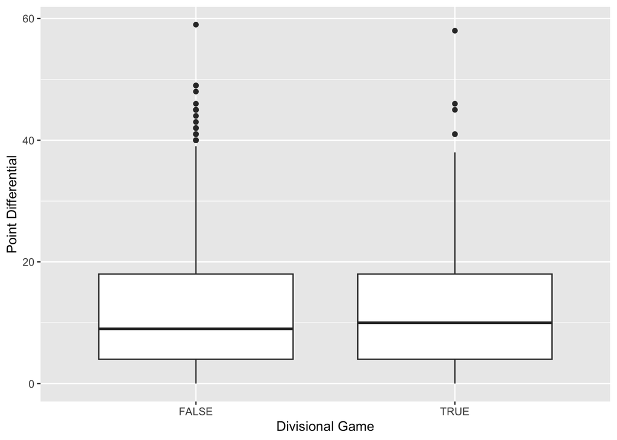

```r
# Create a box plot of point differentials by game type

ggplot(nfl_data, aes(x = divisional_game, y = abs(score_home - score_away))) +
  geom_boxplot() +
  labs(x = "Divisional Game", y = "Point Differential")
```

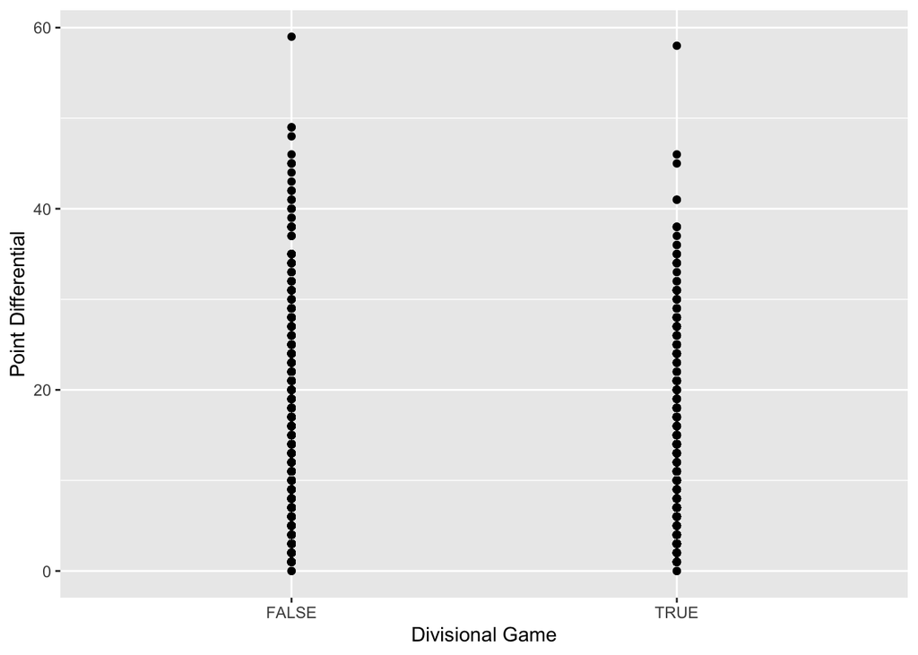

```r
ggplot(nfl_data, aes(x = divisional_game, y = abs(score_home - score_away))) +
  geom_point() +
  labs(x = "Divisional Game", y = "Point Differential")
```

###Question 2 ####Are spreads diferent for divisional games? ###Expectation ####divisional games have a lower spreads.

```r
df2 <- nfl_data %>%
  group_by(divisional_game) %>%
  summarize(mean_spread = mean(abs(score_home - score_away) - abs(spread_favorite)))
summary(df2)
```

```
##   mean_spread
##  Min.   :6.542
##  1st Qu.:6.542
##  Median :6.542
##  Mean   :6.542
##  3rd Qu.:6.542
##  Max.   :6.542
```

```r
df2 <- lm(spread_favorite~divisional_game, data = nfl_data)
summary(df2)
```

```
##
## Call:
## lm(formula = spread_favorite ~ divisional_game, data = nfl_data)
##
## Residuals:
##     Min      1Q  Median      3Q     Max
## -21.070  -1.570   1.024   2.430   5.524
##
## Coefficients:
##                     Estimate Std. Error t value Pr(>|t|)
## (Intercept)         -5.42971    0.09233 -58.809   <2e-16 ***
## divisional_gameTRUE -0.09394    0.15074  -0.623    0.533
## ---
## Signif. codes:  0 '***' 0.001 '**' 0.01 '*' 0.05 '.' 0.1 ' ' 1
##
## Residual standard error: 3.508 on 2309 degrees of freedom
## Multiple R-squared:  0.0001682,  Adjusted R-squared:  -0.0002649
## F-statistic: 0.3883 on 1 and 2309 DF,  p-value: 0.5332
```

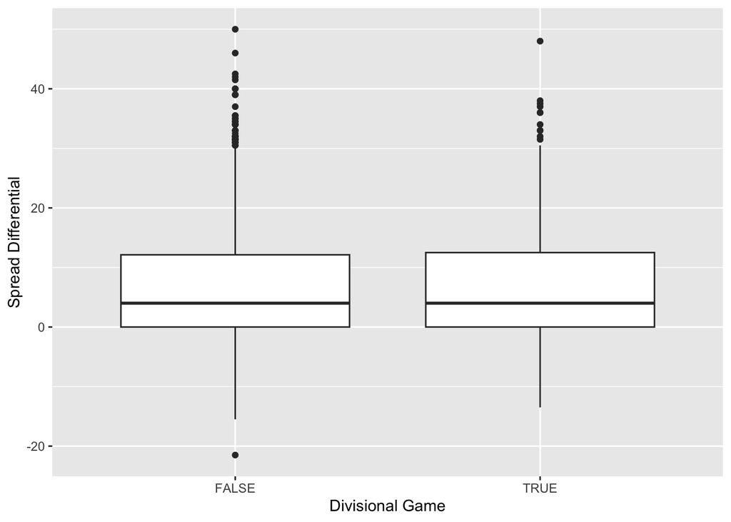

```r
ggplot(nfl_data, aes(x = divisional_game, y = abs(score_home - score_away) - abs(spread_favorite))) +
  geom_boxplot() +
  labs(x = "Divisional Game", y = "Spread Differential")
```

```r
df3 <- nfl_data %>%
  group_by(divisional_game) %>%
  summarize(mean_game_total = mean(score_home + score_away))
summary(df3)
```

```
##  mean_game_total
##  Min.   :42.71
##  1st Qu.:42.71
##  Median :42.71
##  Mean   :42.71
##  3rd Qu.:42.71
##  Max.   :42.71
```

```r
df3 <- lm(total~divisional_game, data = nfl_data)
summary(df3)
```

```
##
## Call:
## lm(formula = total ~ divisional_game, data = nfl_data)
##
## Residuals:
##     Min      1Q  Median      3Q     Max
## -40.188 -10.188  -0.188   8.812  64.097
##
## Coefficients:
##                     Estimate Std. Error t value Pr(>|t|)
## (Intercept)          43.1877     0.3767 114.632   <2e-16 ***
## divisional_gameTRUE  -1.2846     0.6151  -2.088   0.0369 *
## ---
## Signif. codes:  0 '***' 0.001 '**' 0.01 '*' 0.05 '.' 0.1 ' ' 1
##
## Residual standard error: 14.32 on 2309 degrees of freedom
## Multiple R-squared:  0.001885,   Adjusted R-squared:  0.001453
## F-statistic: 4.361 on 1 and 2309 DF,  p-value: 0.03687
```

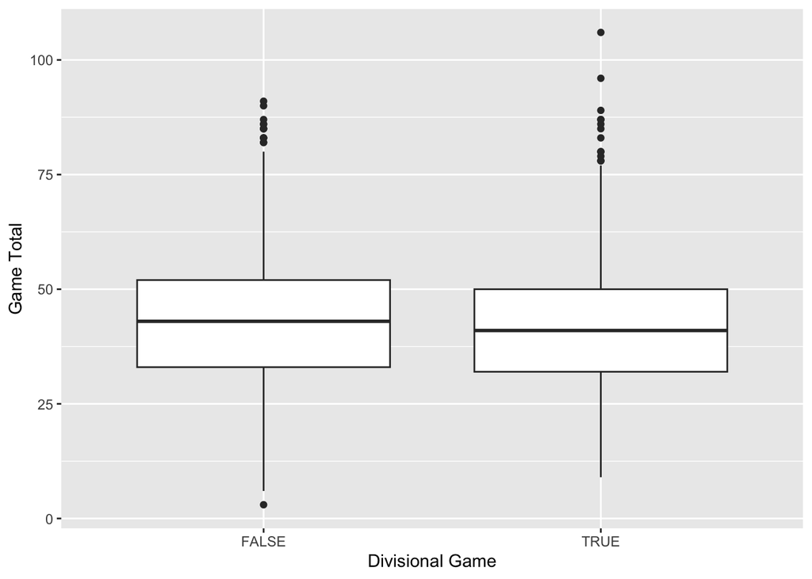

```r
ggplot(nfl_data, aes(x = divisional_game, y = score_home + score_away)) +
  geom_boxplot() +
  labs(x = "Divisional Game", y = "Game Total")
```

###Question 4 ####Are over/under lines diferent for divisional games ###Expectation #####divisional games have a lower over_unders compared to none_divisional games.

```r
df4 <- nfl_data %>%
  group_by(divisional_game) %>%
  summarize(mean_over_under = mean(over_under_line))

summary(df4)
```

```
##  mean_over_under
##  Min.   :41.83
##  1st Qu.:41.83
##  Median :41.83
##  Mean   :41.83
##  3rd Qu.:41.83
##  Max.   :41.83
```

```r
df4 <- lm(over_under_line~divisional_game, data = nfl_data)
summary(df4)
```

```
##
## Call:
## lm(formula = over_under_line ~ divisional_game, data = nfl_data)
##
## Residuals:
##      Min       1Q   Median       3Q      Max
## -11.7428  -3.7428  -0.2428   3.1125  18.2572
##
## Coefficients:
##                     Estimate Std. Error t value Pr(>|t|)
## (Intercept)          41.8875     0.1224 342.319   <2e-16 ***
## divisional_gameTRUE  -0.1447     0.1998  -0.724    0.469
## ---
## Signif. codes:  0 '***' 0.001 '**' 0.01 '*' 0.05 '.' 0.1 ' ' 1
##
## Residual standard error: 4.65 on 2309 degrees of freedom
## Multiple R-squared:  0.0002271,  Adjusted R-squared:  -0.0002059
## F-statistic: 0.5244 on 1 and 2309 DF,  p-value: 0.469
```